# FARMR!SK automatic report

The main pathways of disease entry are: **Animal transport** and **Wildlife**.

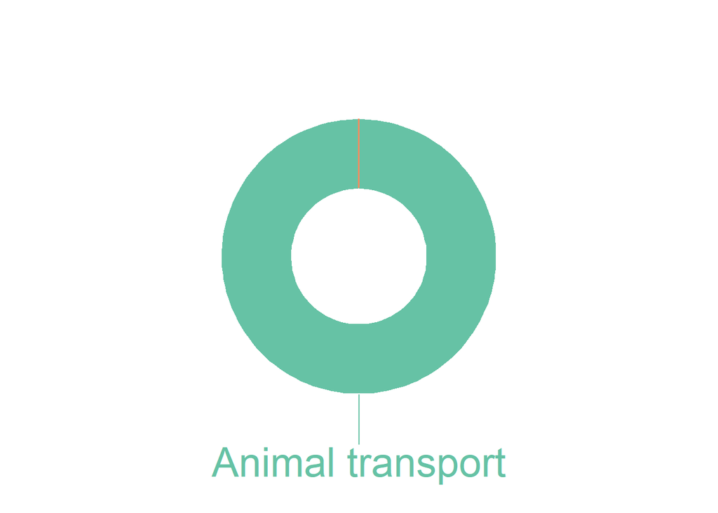

(a) IBR

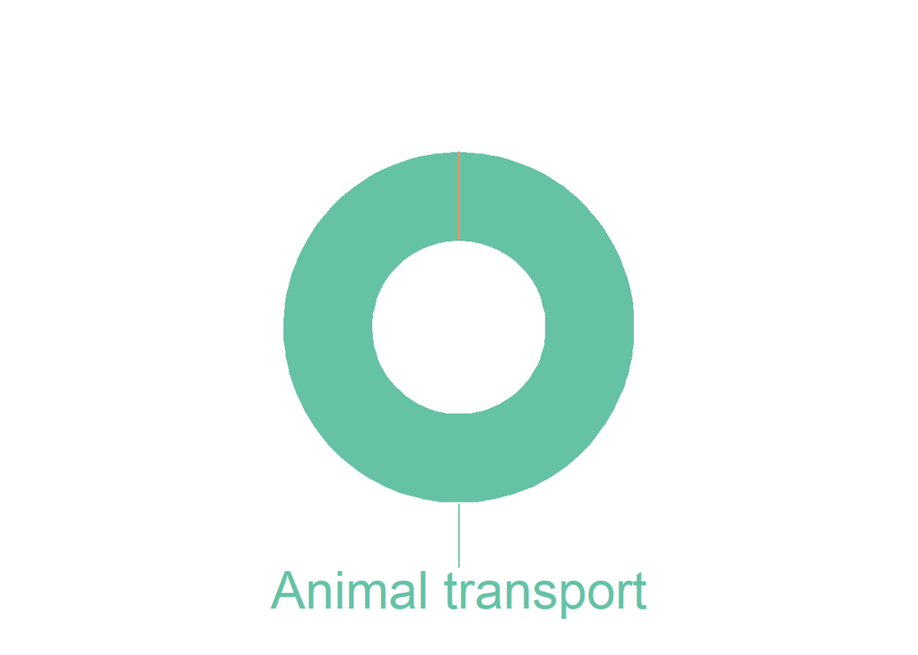

(b) BVD

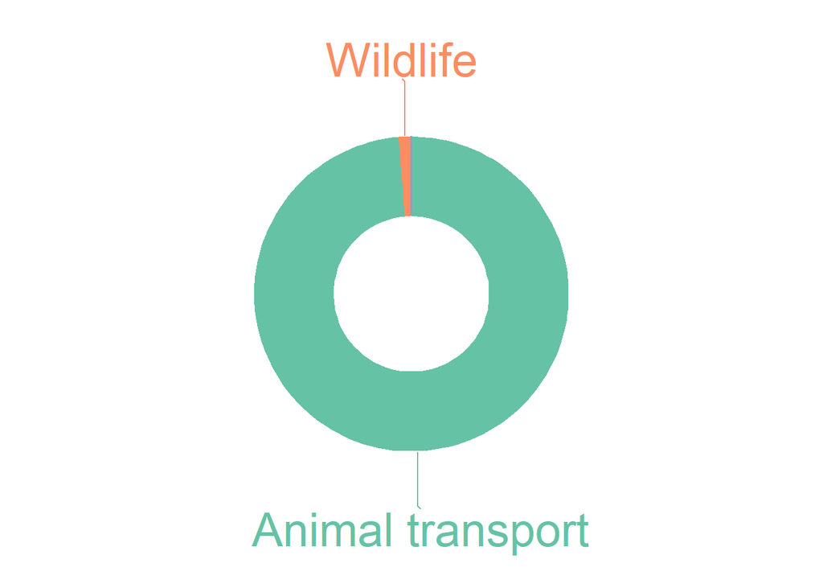

(c) TB

Figure 1.2: Risk of disease entry by pathway

## **Infectious Bovine Rhinotracheitis (IBR)**

### Current risk

Annual risk of IBR entry in the farm: **98.6%** (92.7-99.9%)

By pathway:

- Animal transport: **98.6%** (92.8-99.9%)
- Vehicle visits to the farm: **0.000784%** (1.12e-05-0.00418%)

### Risk reduction of biosecurity measures

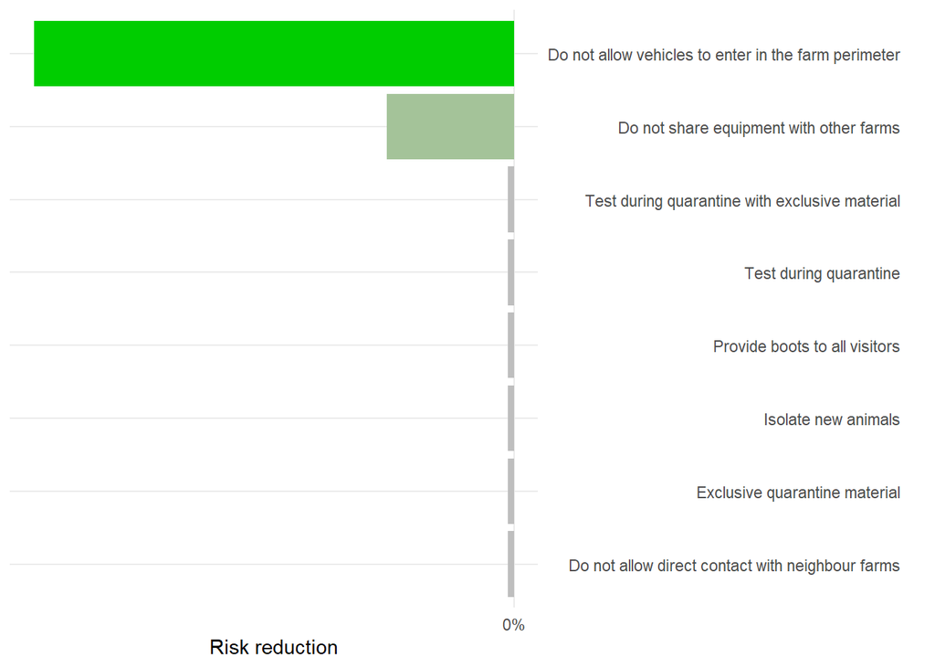

## **Bovine viral diarrhea (BVD)**

### Current risk

By pathway:

- Animal transport: **7.62%** (1.78-24%)
- Vehicle visits to the farm: **0.000588%** (9.12e-06-0.00368%)

### Risk reduction of biosecurity measures

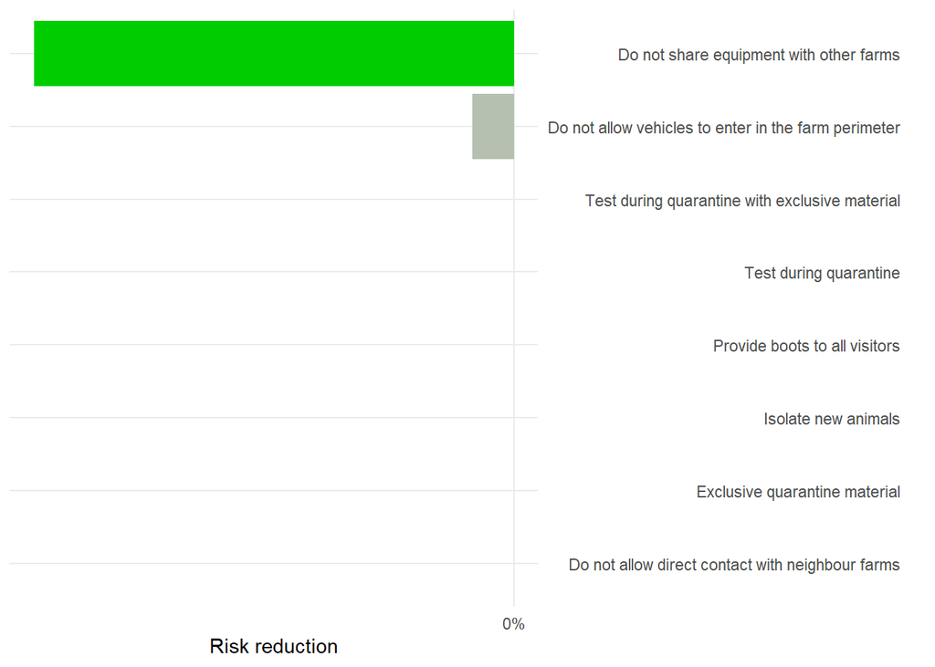

## **Bovine Tuberculosis (TB)**

### Current risk

Annual risk of TB entry in the farm: **0.217%** (0.0857-0.429%)

By pathway:

- Animal transport: **0.217%** (0.0856-0.428%)
- Wildlife: **0.00274%** (0.00031-0.0146%)
- Vehicle visits to the farm: **1.81e-08%** (3.33e-13-1.72e-06%)

### Risk reduction of biosecurity measures

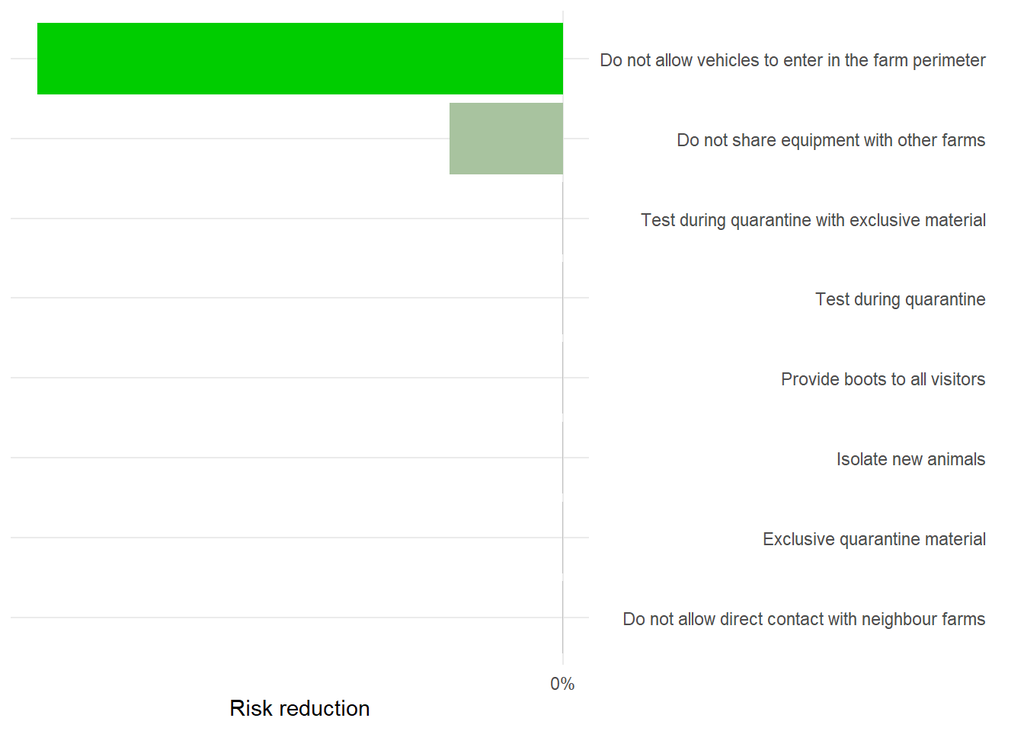

# 🐄 Description of the farm

## Farm information

**Farm type:** Beef cattle, NA

**Cattle cens:**

- 90 Calves ( <8 m)
- 30 Heifers (8 - 24 m)
- 85 Adult cows (>24 m)
- 9 Bulls

**Other animals in the farm:**

- **Direct contact with cattle:** 20 sheep, 10 goats, 8 cats, 3 horses, 3 donkeys
- **No direct contact with cattle:**

**Neighbours**: No cattle farms within a 1-2km radious (negligible risk)

## Farm vehicles

| veh_id | Size | Shared | Cleaning |
| --- | --- | --- | --- |
| Remolc compartit (a) | 10m2 | Shared with 2 cattle farms | From time to time |
| Remolc vintage (b) | 20m2 | Shared with 4 cattle farms | From time to time |

## Visits

### People entering the barn

[output not shown]

### Vehicles entering the farm perimeter

| Visit | Type | Frequency | Driver | Risk |
| --- | --- | --- | --- | --- |
| Pinso | Feed vehicle | 30 | - | IBR: 0.000784%, BVD: 0.000588%, TB: 1.81e-08% |

# 🚚 Movements

Animal movements in the last 12 months

| mov_id | When | Origin | Animals moved | Shared site | Vehicle used | Risk |
| --- | --- | --- | --- | --- | --- | --- |
| pastures_estiu | 🔁 Recurrent round: 1 times/year, out for 15 days | Pasture: Andorra | 60 Calves ( <8 m), 25 Heifers (8 - 24 m), 70 Adult cows (>24 m), 9 Bulls | No | External | IBR: 98.6%, BVD: 7.62%, TB: 0.217% |

### Health status and tests in origin

| mov_id | Pathogen | Health status in origin | Test in origin |
| --- | --- | --- | --- |
| pastures_estiu | BVD | Unknown | - |
|  | IBR |  |  |
|  | TB |  |  |

### Quarantine

#### Characteristics

*No quarantine*

# 🐗 Wildlife

**Wildlife:** IBR: -, BVD: -, TB: 0.00274%

- Outdoors grazing: Outdoors grazing, complete perimeter fence, wildlife can access the farm (simple) (IBR: -, BVD: -, TB: 7.56e-09%)
- Pasture (trashumance): No pastures

### Farm water points

| Waterpoints | Mud |
| --- | --- |
| 100% High waterer (>90cm) | 0% |

### Pasture water points

*No pasture water points*

# Comments

*No survey comments*

# Technical Annex

- Simulation date: 2025-11-18 12:23:13
- Script unification date: 2025-11-17 12:20:43
- Repository: https://github.com/NataliaCiria/biosecurity_model.git
- Last commit: 5b482c75a9928a4d9b1dd0f39f59ed7d93bb09e0
- Last commit date: 2025-11-16 17:22:55
- user_id:
- farm_id: bc4_v2
- Risk timeframe: 360 days
- Calculate all summaries: FALSE
- Automatic what-if scenarios: TRUE
- Analyse model sensitivity: FALSE
- Farm biosecurity survey: bsg_cattle_v4_2_mod_ciria 2014-05-16
- Movements surveys:
  - v4_1_ciria ( 1 ): pastures_estiu